# Red Wine Quality Analysis by Jake Williams

This report is going to be exploring a dataset containing 13 different variables in red wine. We will be analyzing the data to figure out what defines ‘**quality**’.

### DISCLAIMER:

This dataset is public available for research. The details are described in [Cortez et al., 2009].

P. Cortez, A. Cerdeira, F. Almeida, T. Matos and J. Reis. Modeling wine preferences by data mining from physicochemical properties. In Decision Support Systems, Elsevier, 47(4):547-553. ISSN: 0167-9236.

[@Elsevier] http://dx.doi.org/10.1016/j.dss.2009.05.016 [Pre-press (pdf)] http://www3.dsi.uminho.pt/pcortez/winequality09.pdf [bib] http://www3.dsi.uminho.pt/pcortez/dss09.bib

# Univariate Plots Section

To begin, I want to get the structure of the data, meaning I want to see what makes up our dataset as a whole.

```
## 'data.frame':    1599 obs. of  13 variables:
##  $ X                   : int  1 2 3 4 5 6 7 8 9 10 ...
##  $ fixed.acidity       : num  7.4 7.8 7.8 11.2 7.4 7.4 7.9 7.3 7.8 7.5 ...
##  $ volatile.acidity    : num  0.7 0.88 0.76 0.28 0.7 0.66 0.6 0.65 0.58 0.5 ...
##  $ citric.acid         : num  0 0 0.04 0.56 0 0 0.06 0 0.02 0.36 ...
##  $ residual.sugar      : num  1.9 2.6 2.3 1.9 1.9 1.8 1.6 1.2 2 6.1 ...
##  $ chlorides           : num  0.076 0.098 0.092 0.075 0.076 0.075 0.069 0.065 0.073 0.071 ...
##  $ free.sulfur.dioxide : num  11 25 15 17 11 13 15 15 9 17 ...
##  $ total.sulfur.dioxide: num  34 67 54 60 34 40 59 21 18 102 ...
##  $ density             : num  0.998 0.997 0.997 0.998 0.998 ...
##  $ pH                  : num  3.51 3.2 3.26 3.16 3.51 3.51 3.3 3.39 3.36 3.35 ...
##  $ sulphates           : num  0.56 0.68 0.65 0.58 0.56 0.56 0.46 0.47 0.57 0.8 ...
##  $ alcohol             : num  9.4 9.8 9.8 9.8 9.4 9.4 9.4 10 9.5 10.5 ...
##  $ quality             : int  5 5 5 6 5 5 5 7 7 5 ...
```

By looking at the summary above, our dataset contains 13 variables that we will explore further. We can quickly notice that there is one variable that is only serving as an index, variable ‘X’. This will be omitted from our studies and now we have 12 variables left to explore.

Let’s get an overview of these variables by looking at each as a histogram. This will give us a better understanding of how red wines are distributed across our dataset. Our X axis will display each variable while the Y axis will be our number of wines.

```
##      values     ind
## 1  4.600000    Min.
## 2  7.100000 1st Qu.
## 3  7.900000  Median
## 4  8.319637    Mean
## 5  9.200000 3rd Qu.
## 6 15.900000    Max.
```

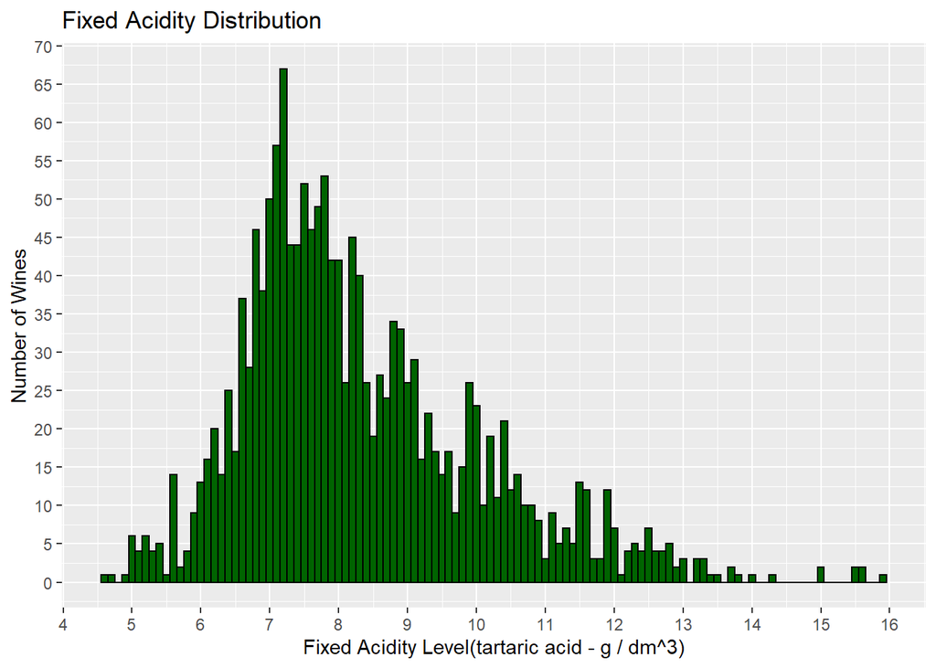

Our first graph displays the fixed acidity distribution in our dataset. Most of the red wine appears to fall between the 6.5 and 8.5 range.

```
##      values     ind
## 1 0.1200000    Min.
## 2 0.3900000 1st Qu.
## 3 0.5200000  Median
## 4 0.5278205    Mean
## 5 0.6400000 3rd Qu.
## 6 1.5800000    Max.
```

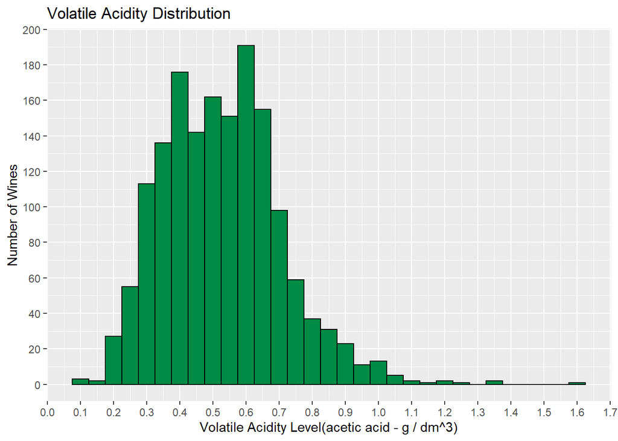

Volatile acidity is measured in lower amounts with a majority of wines between .3 and .7.

```
##      values     ind
## 1 0.0000000    Min.
## 2 0.0900000 1st Qu.
## 3 0.2600000  Median
## 4 0.2709756    Mean
## 5 0.4200000 3rd Qu.
## 6 1.0000000    Max.
```

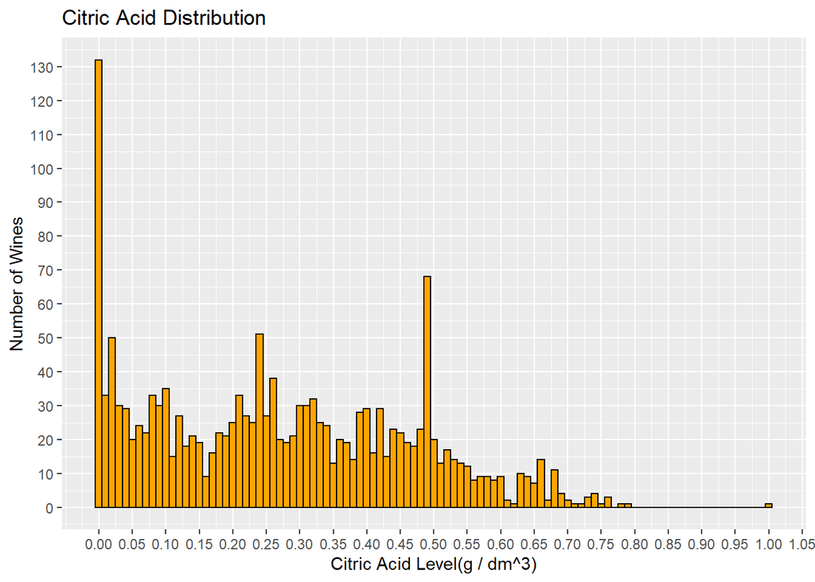

Citric acid levels are interesting. Over 130 wines have close to a 0 citric acid level while another larger portion of wines has closer to .5.

```
##      values     ind
## 1  0.900000    Min.
## 2  1.900000 1st Qu.
## 3  2.200000  Median
## 4  2.538806    Mean
## 5  2.600000 3rd Qu.
## 6 15.500000    Max.
```

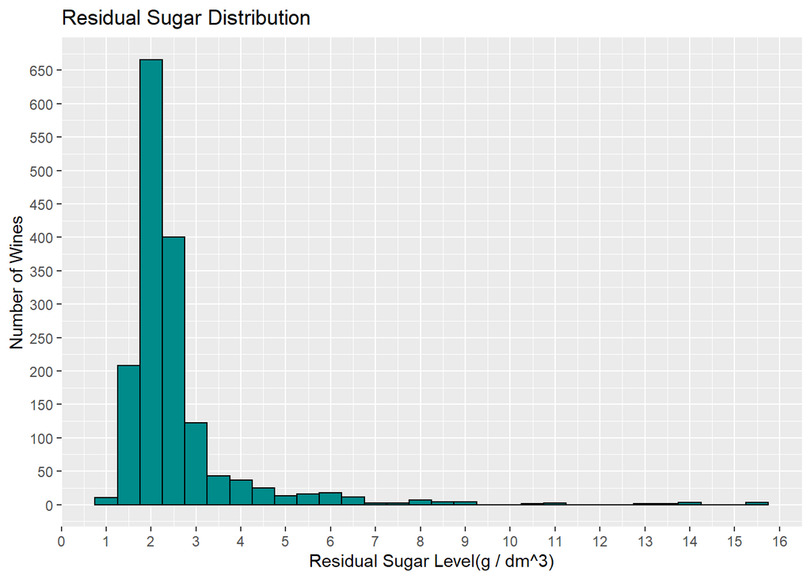

Red wines with low residual sugar levels are much more common than higher levels. Over 650 wines alone stay around 2.

```
##       values     ind
## 1 0.01200000    Min.
## 2 0.07000000 1st Qu.
## 3 0.07900000  Median
## 4 0.08746654    Mean
## 5 0.09000000 3rd Qu.
## 6 0.61100000    Max.
```

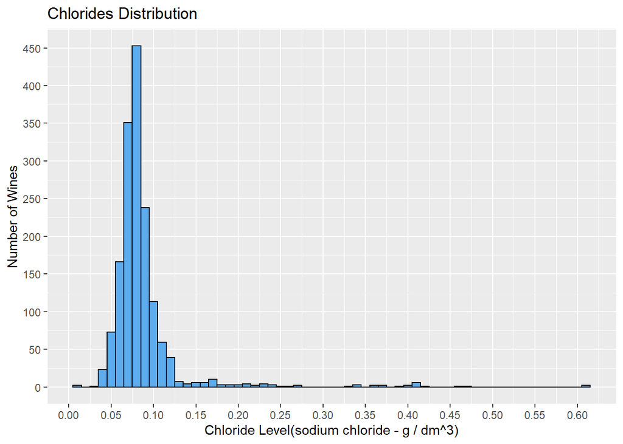

Similar to residual sugar, the level of chlorides in red wine are staying more at the lower end. I wonder if a higher chloride level affects taste.

```
##     values     ind
## 1  1.00000    Min.
## 2  7.00000 1st Qu.
## 3 14.00000  Median
## 4 15.87492    Mean
## 5 21.00000 3rd Qu.
## 6 72.00000    Max.
```

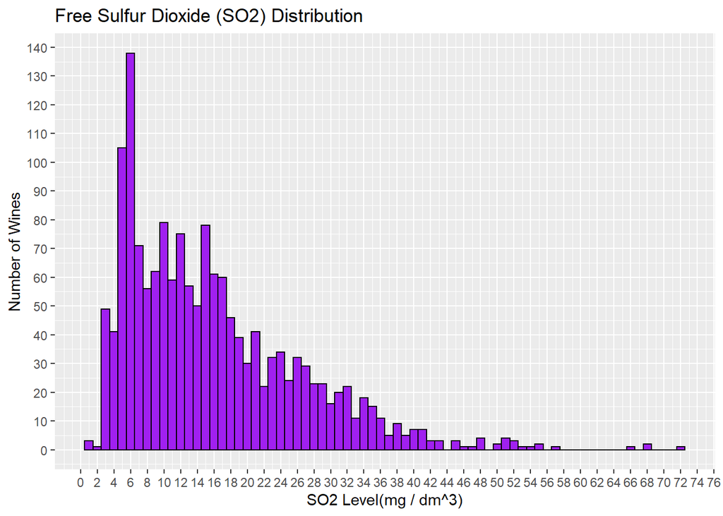

SO2 distribution appears to have a more of a ‘consistent’ drop in wines as the levels increase, with a few exceptions here and there.

```
##      values     ind
## 1   6.00000    Min.
## 2  22.00000 1st Qu.
## 3  38.00000  Median
## 4  46.46779    Mean
## 5  62.00000 3rd Qu.
## 6 289.00000    Max.
```

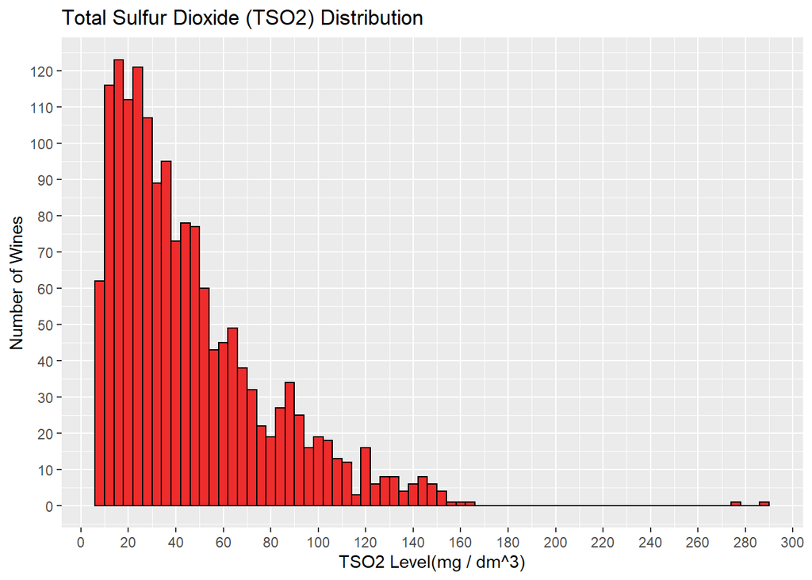

Most red wine in our dataset TSO2 levels between 0 and 50. We can also note some outliers after a large gap in the data.

```
##      values     ind
## 1 0.9900700    Min.
## 2 0.9956000 1st Qu.
## 3 0.9967500  Median
## 4 0.9967467    Mean
## 5 0.9978350 3rd Qu.
## 6 1.0036900    Max.
```

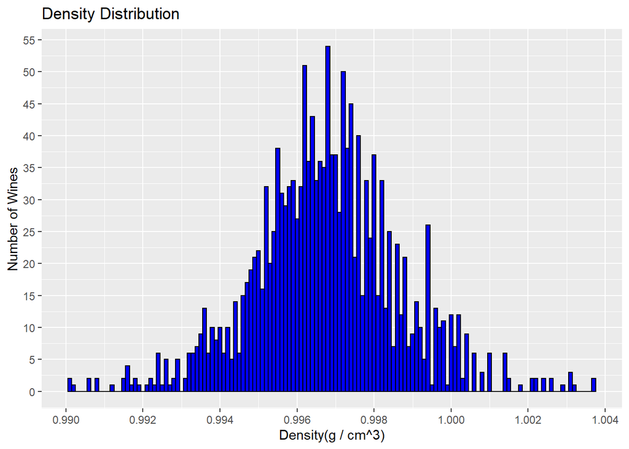

Density is interesting as a majority of the wines in our dataset fall between .995 and .998 levels. This graph depicts more of a normal distribution.

```
##     values     ind
## 1 2.740000    Min.
## 2 3.210000 1st Qu.
## 3 3.310000  Median
## 4 3.311113    Mean
## 5 3.400000 3rd Qu.
## 6 4.010000    Max.
```

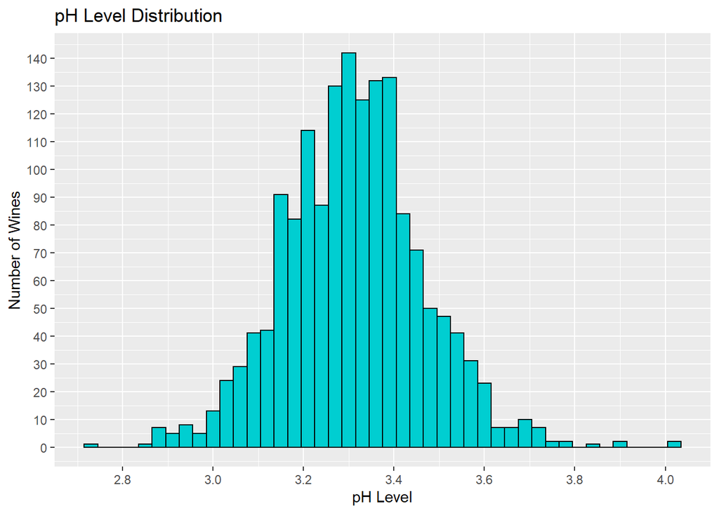

pH level also shows a more normal distribution with red wine. 3.3-3.4 seems to be the sweet spot for most wines.

```
##      values     ind
## 1 0.3300000    Min.
## 2 0.5500000 1st Qu.
## 3 0.6200000  Median
## 4 0.6581488    Mean
## 5 0.7300000 3rd Qu.
## 6 2.0000000    Max.
```

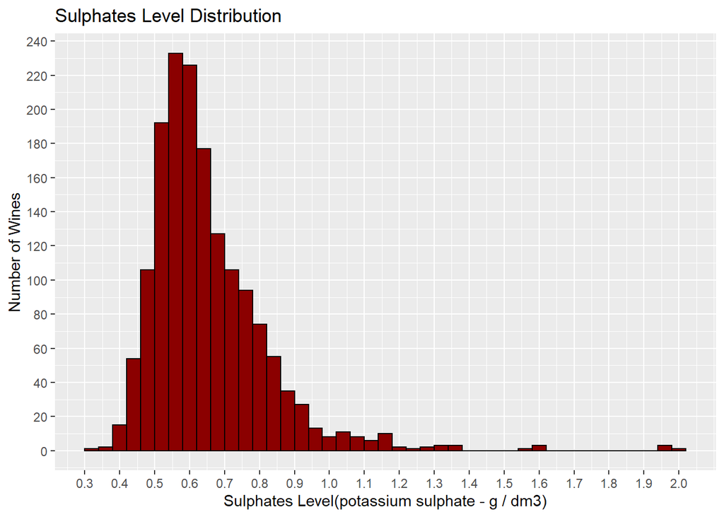

Lower level sulphates appear to be much more common than higher levels, with less than 20 going past 1.5. Is higher quality more common with lower levels?

```
##     values     ind
## 1  8.40000    Min.
## 2  9.50000 1st Qu.
## 3 10.20000  Median
## 4 10.42298    Mean
## 5 11.10000 3rd Qu.
## 6 14.90000    Max.
```

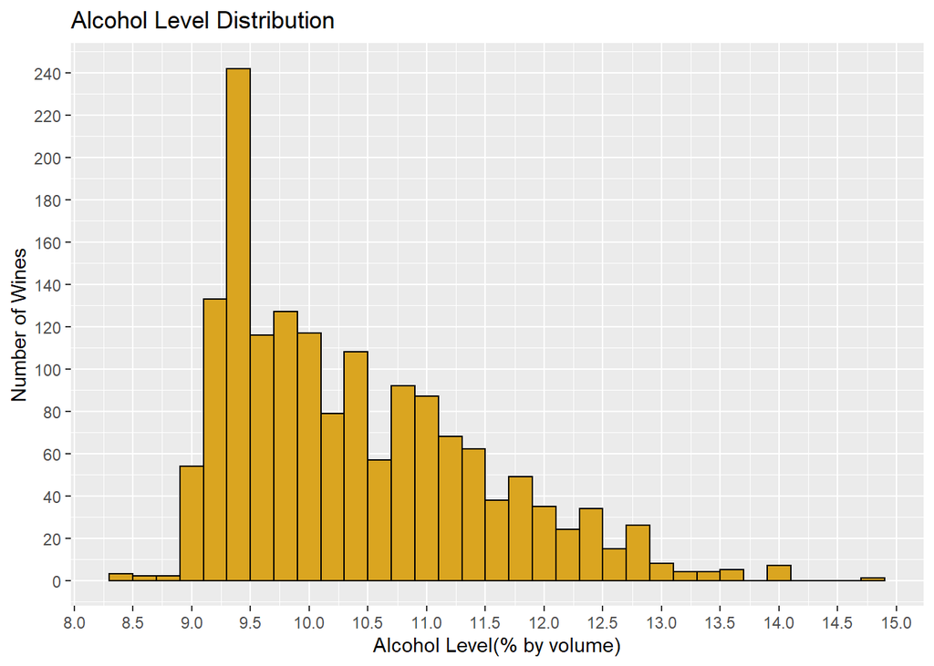

I was interested to see how alcohol level is distributed for red wine. Right under a 9.5 alcohol level is most common with almost double the amount of wines as the next highest distribution.

```
##     values     ind
## 1 3.000000    Min.
## 2 5.000000 1st Qu.
## 3 6.000000  Median
## 4 5.636023    Mean
## 5 6.000000 3rd Qu.
## 6 8.000000    Max.
```

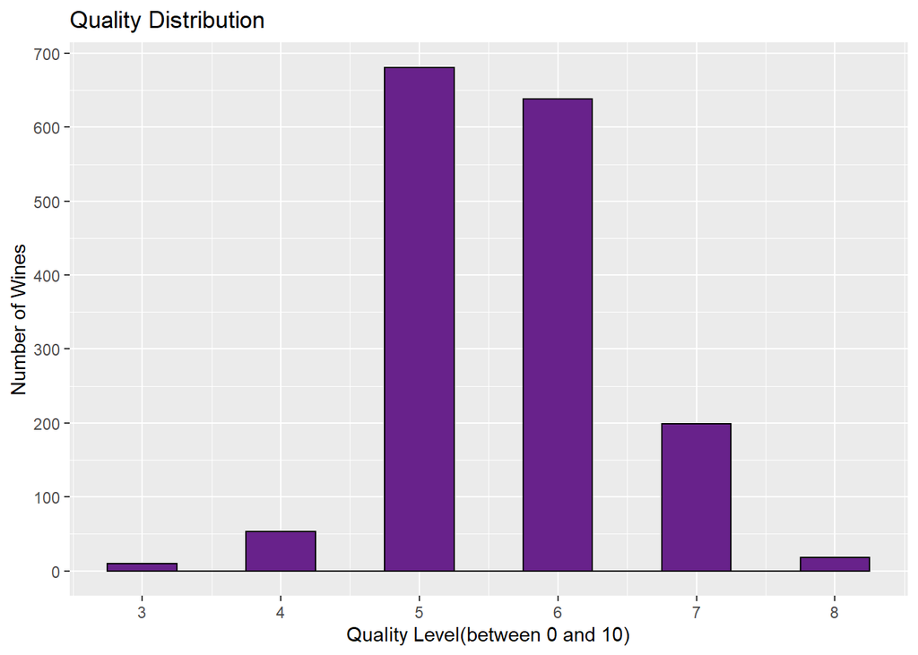

Finally, our quality distribution in the dataset. A majority of red wine falls around 5 and 6 with very few past a 7 rating. Judging wine quality must be very strict.

# Univariate Analysis

### What is the structure of your dataset?

There are 1599 red wines in the dataset with 12 variables(fixed acidity, volatile acidity, citric acid, residual sugar, chlorides, free sulfur dioxide total sulfur dioxide, density , pH, sulphates, alcohol, quality) that determine the quality of red wine. ‘X’ is considered a 13th variable in the dataset but only serves the purpose of indexing. Many of the variables deal with smaller decimals as their values.

### What is/are the main feature(s) of interest in your dataset?

Quality is the main feature in this dataset. I want to take a deeper dive into what determines how a wine is rated.

### What do you think will help support your investigation?

I was first wanting looking at alcohol level and residual sugar, but I want to view the correlation of each variable to see what will play a role in how quality is measured. A majority of people like sugar and alcohol, so I feel like they will play a large part in red wine quality.

### Did you create any new variables from existing variables in the dataset?

No new variables were created from existing variables.

### Any unsual distributions or adjustments to the form of the data?

Over half of the graphs had some outliers in the data such as volatile acidity, citric acid, residual sugar, chlorides, free sulfur dioxide, total sulfur dioxide, and sulphates. Other graphs appeared to have outliers but there weren’t as many as those mentioned.

A few variables also seemed to be ‘long tailed’ such as residual sugar, chlorides and free sulfur dioxide.

For each of these operations, I adjusted each of their axis ranges as well as bin width to better understand the distributions of the variable’s data. Even though these histograms are considered simplistic, one could put more variables in lists depending on how the data’s form was manipulated/plotted.

I also added color to the graphs to give it more of an easier to read visual.

# Bivariate Plots Section

A better visual for relationships in the data can be shown by viewing correlation levels. Based on the graph, I want to explore variables that have a strong correlation with one another.

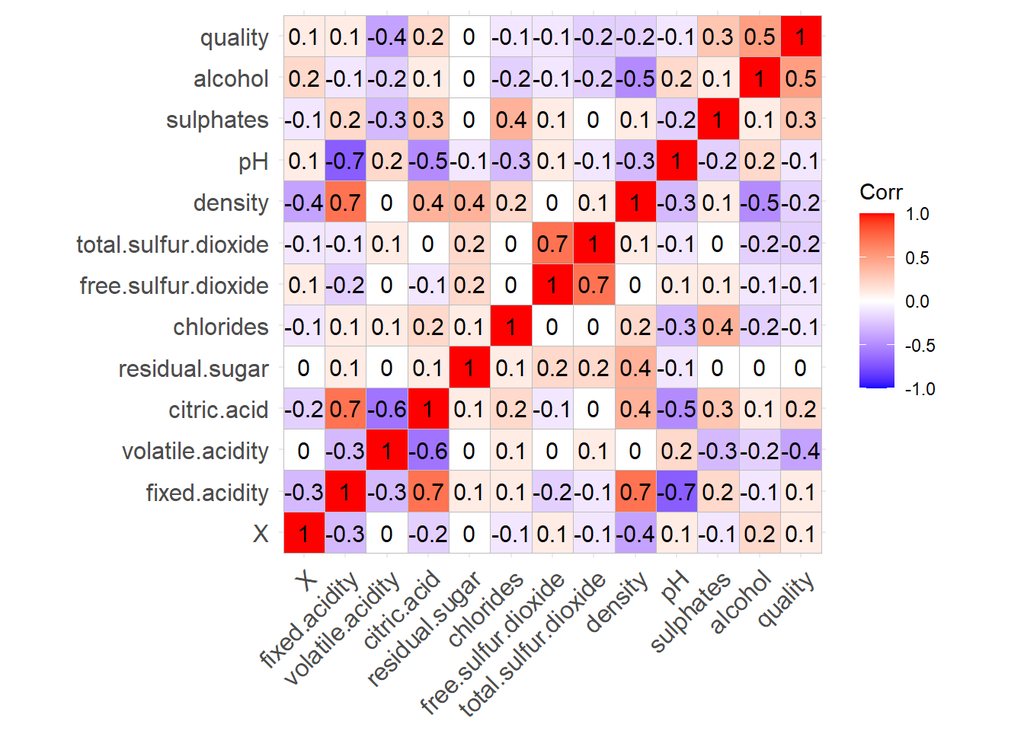

A strong correlation is defined by a higher positive number on the scale, and is represented by the color red. The darker the shade of red, the higher the correlation. To read this graph, we simply take one variable from the x axis and one variable from the y axis then find where the two intersect.

Correlation values have been rounded to provide an easier to read format.

Based on the visualization, some of the strongest correlation with variables are:

**Density** and **Fixed Acidity** (.7)  
**Citric Acid** and **Fixed Acidity** (.7)  
**Total Sulfur Dioxide(TSO2)** and **Free Sulfur Dioxide(SO2)** (.7)

While quality seems to have the strongest correlation with:

**Citric Acid** (.2)  
**Sulphates** (.3)  
**Alcohol** (.5)

While some of the weakest correlation is:

**pH** and **Fixed Acidity** (-.7)  
**Citric Acid** and **Volatile Acidity** (-.6)  
**Alcohol** and **Density** (-.5)

Let’s look at our strong variable correlations and visualize each as a scatter plot.

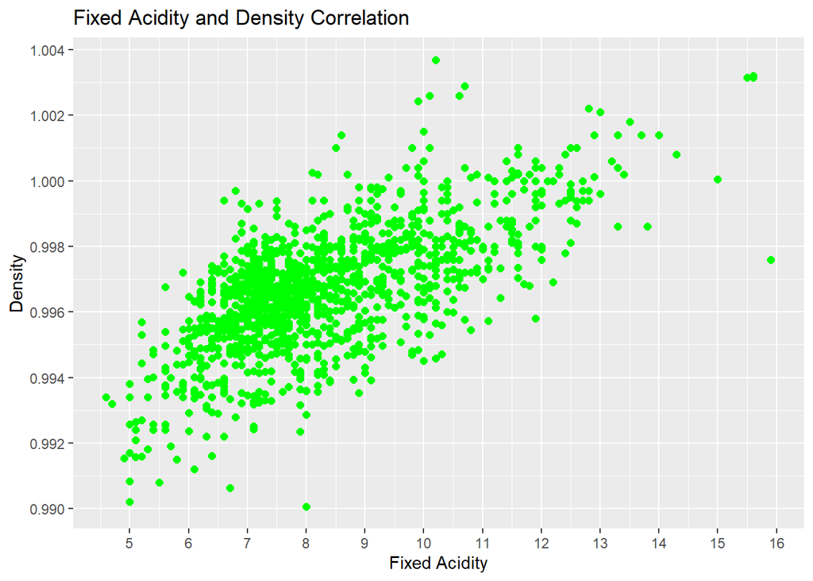

We can clearly see the positive correlation (.7) here with a main focus on acidity levels being between 7 and 8 while density appears to be around the .996 level.

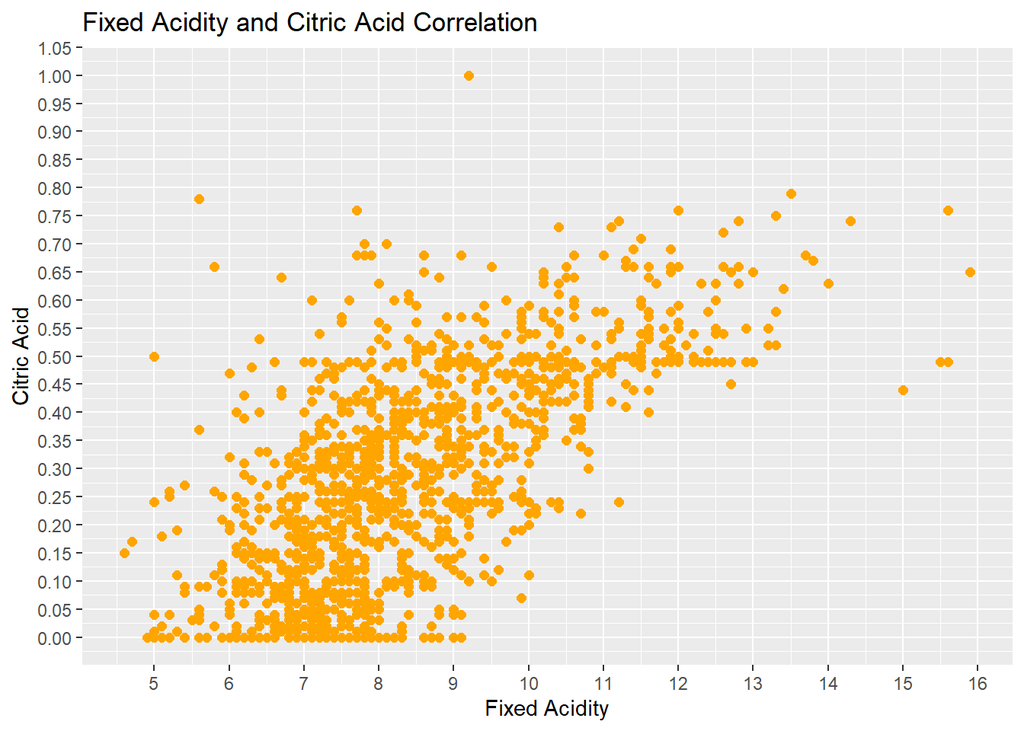

Comparing fixed acidity and citric acid levels show another positive correlation(.7). Little to no citric acid levels (<.05) appear to favor fixed acidity levels betwen 5 and 9.

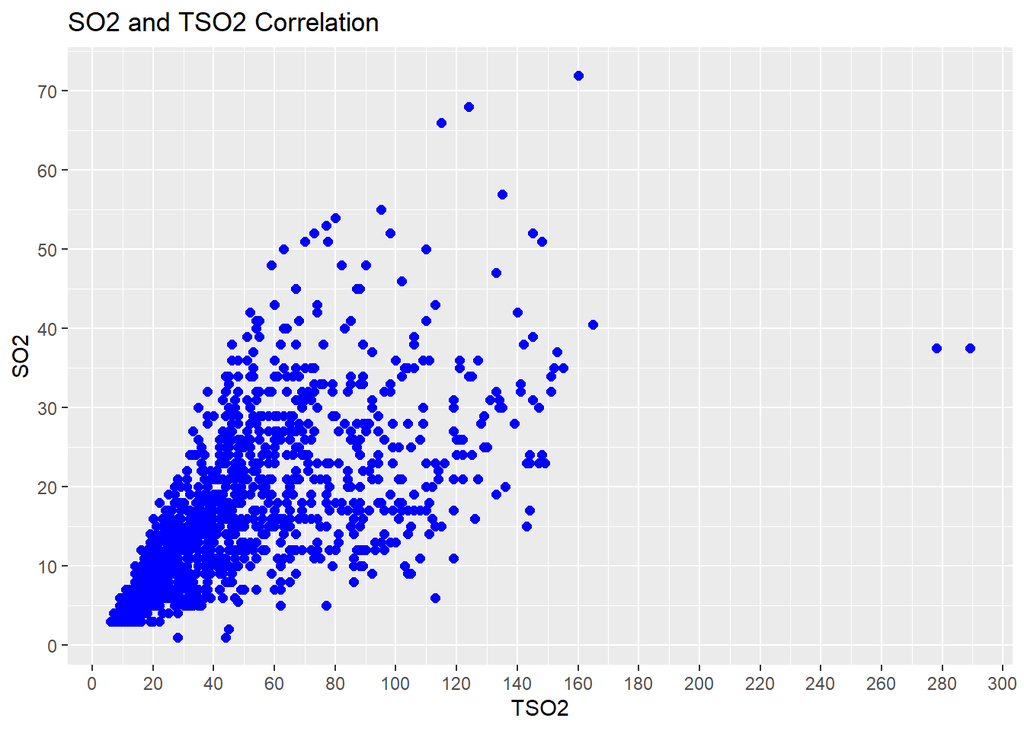

Both total sulfur dioxide and free sulfur dioxide appear to have very strong postive correlation(.7) with the scatter plot being in more of an upwards cone shape. Both values increase together. Most of the correlation does focus on lower levels of both sulfur levels with a few oddities.

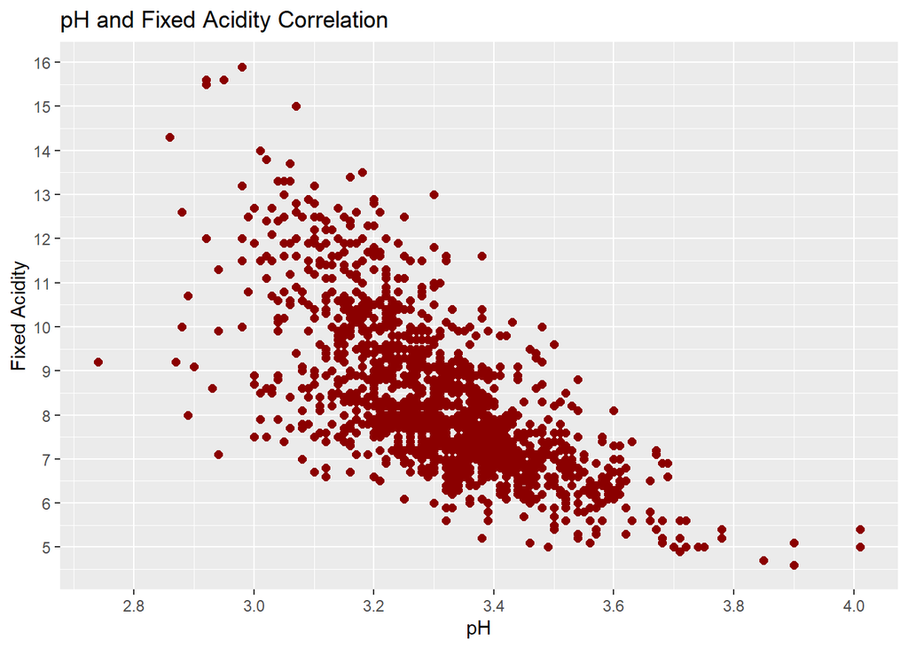

I want to look at a negatively correlated pair, so I chose pH and fixed acidity. The negative correlation(-.7) is clearly defined as there is a noticable downward slope, and shows that as pH levels increase, fixed acidity levels decrease.

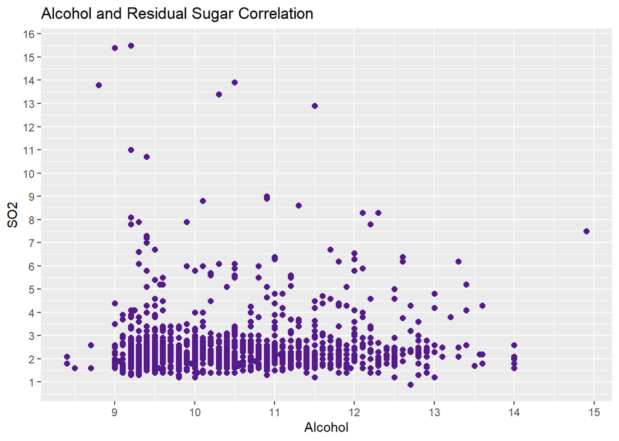

Since I believed that alcohol and residual sugar affected quality, I was curious to see if there was any correlation between the two. By referencing our chart above, there was no correlation(0) due to no indication of an upwards or downwards slope. We can visually see this, however that doesn’t necessarily mean the variables on their own don’t affect quality.

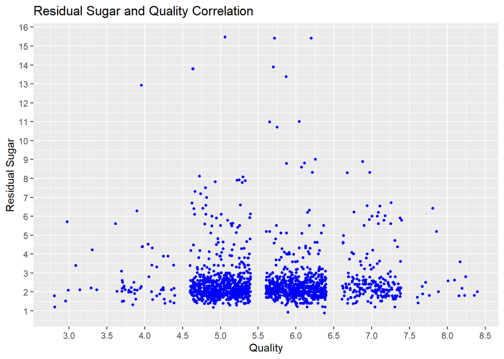

I thought that residual sugar levels would have an effect on the quality of a red wine, however it appears that there is no correlation between them. A majority ofwines are shown to have low residual sugar levels while still increasing in quality.

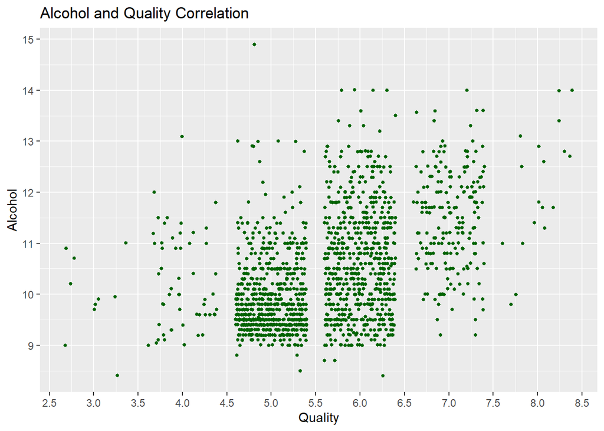

On the flip side, it came to no surprise(to me at least) that alcohol had an effect on quality. We can see that while alcohol level increases, quality does increase more consistently with higher alcohol levels.

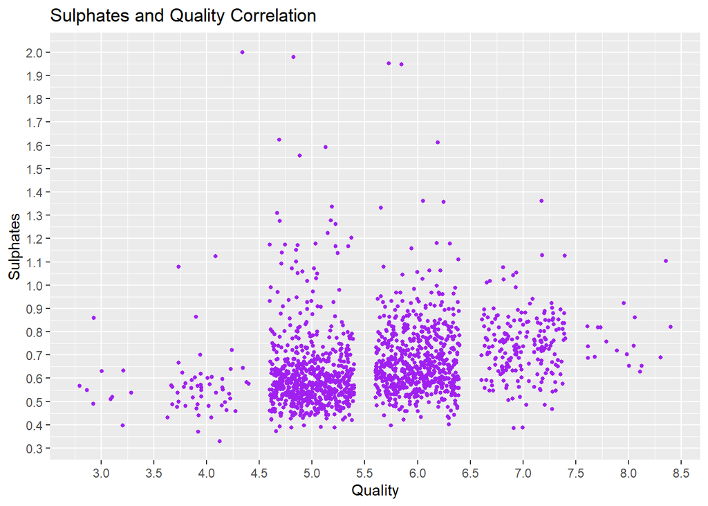

Sulphates have a slight positive correlation with quality. While most red wines are rated between 4.5 and 6.5, you can still notice a slight trend in the data.

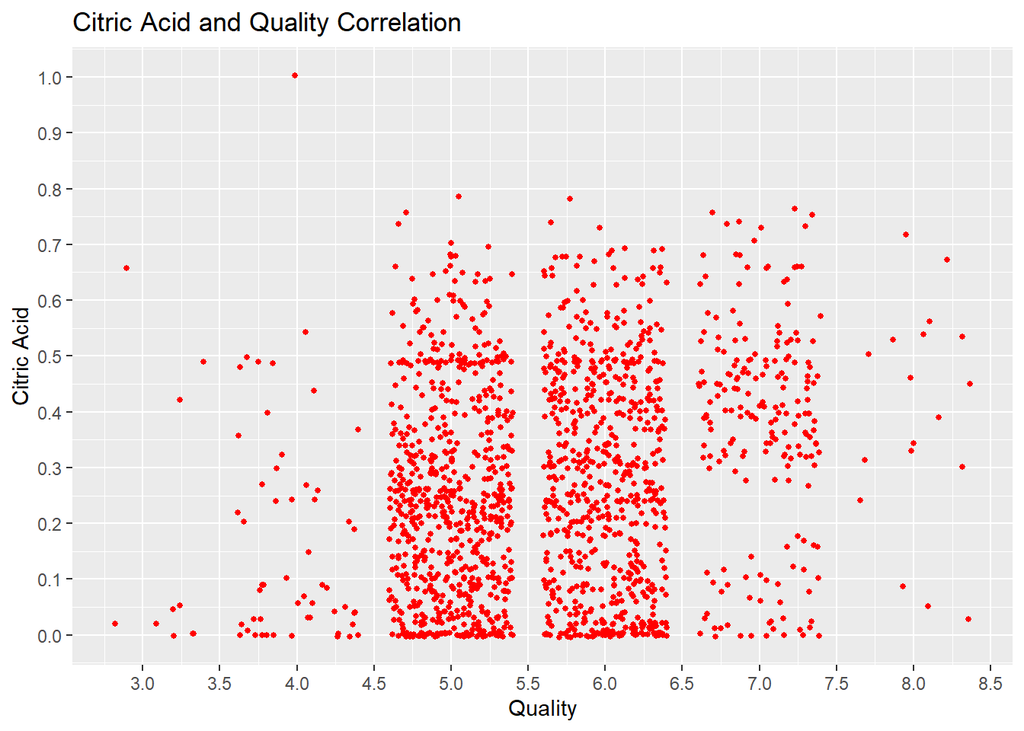

Citric acid is also shown to have a positive correlation with quality.

### Relationships observed and features of interest

I observed three positive correlations in the dataset as well as one negative correlation and one with no correlation. I wanted to get a visual idea as to how the data is distributed between two variables. Two of the positive correlations involved fixed acidity as a variable with density/citric acid as the other variable. Both shared similar distributions with citric acid appearing to have more values closer to zero.

### Did you observe any interesting relationships between the other features?

I was surprised to see that total sulfur dioxide and free sulfur dioxide shared a positive correlation. I was under the impression that one would have a negative impact on the other, similar to putting diesel in a gas engine and vice versa.

### What was the strongest relationship you found?

Density and fixed acidity had the strongest positive correlation because of how it has more of a consistent incline to the data.

pH and fixed acidity had the strongest negative correlation as the trend depicted a sharper decline.

The strongest relationship with quality was alcohol(not surprised).

# Multivariate Plots Section

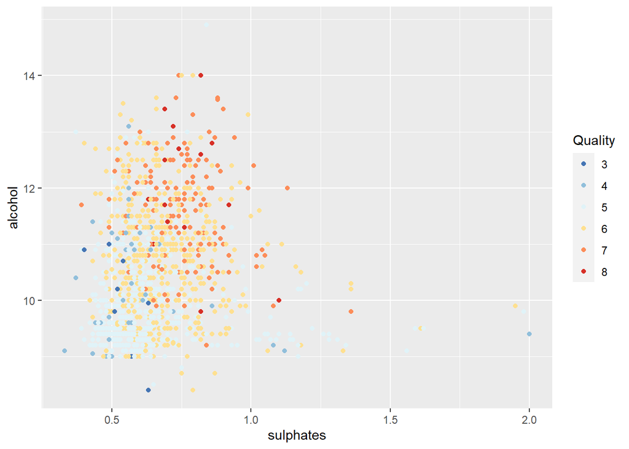

I decided to find out if both alcohol and sulphates had any correlation with the quality of wine since both were the highest correlated variables when separately compared to wine quality. Different colors define the quality score with red being the highest and blue being the lowest. Based on the graph, it actually appears that there is a slgith positive correlation with both alcohol and sulphates.A majority of red wines are rated between 5 and 7 and the colors representing them have a slight incline to them.

Since alcohol has the highest correlation with quality, I want to compare both alcohol and citric acid to see if their interactions show a positive correlation with quality.

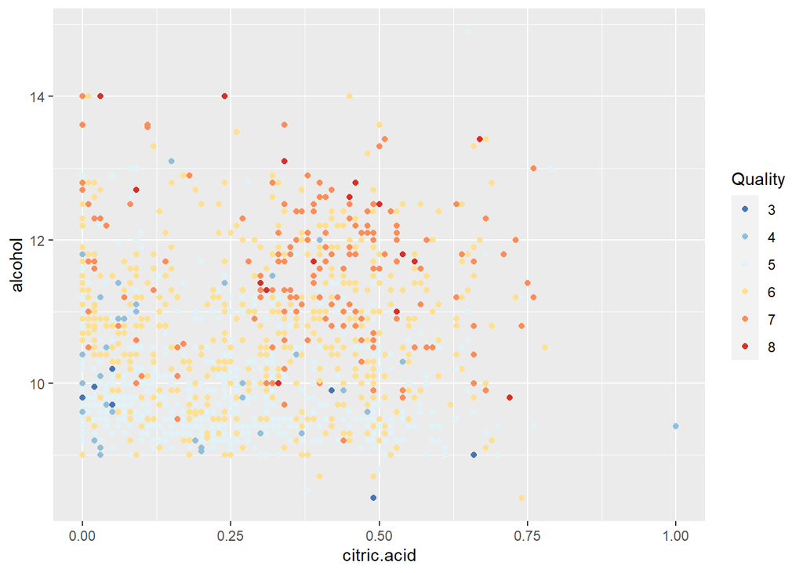

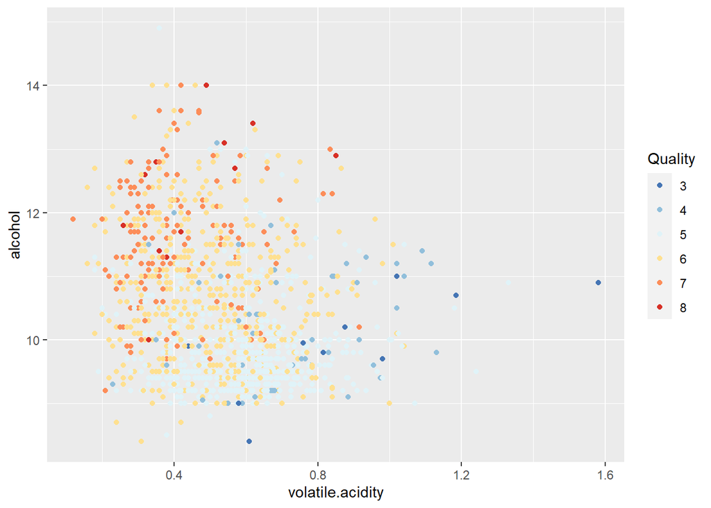

For this final graph, I wanted to look at the highest correlated variable and the lowest correlated variable together and see how quality is depicted. It appears that most mid rated wines fall between the volatile acidity levels of .4 and .8, while alcohol hovers around 9 and 10.

# Multivariate Analysis

Alcohol and sulphates appear to have a very small positive correlation between each other. You can see that there is some trend with the increase of quality, however the amount of sulphates mainly stays near the lower end of the x axis, between .5 and 1.

### Were there any interesting or surprising interactions between features?

It was interesting to see that higher alcohol and citric acid levels together didn’t influence quality scores as much as alcohol and sulphates.

# Final Plots and Summary

### Plot One

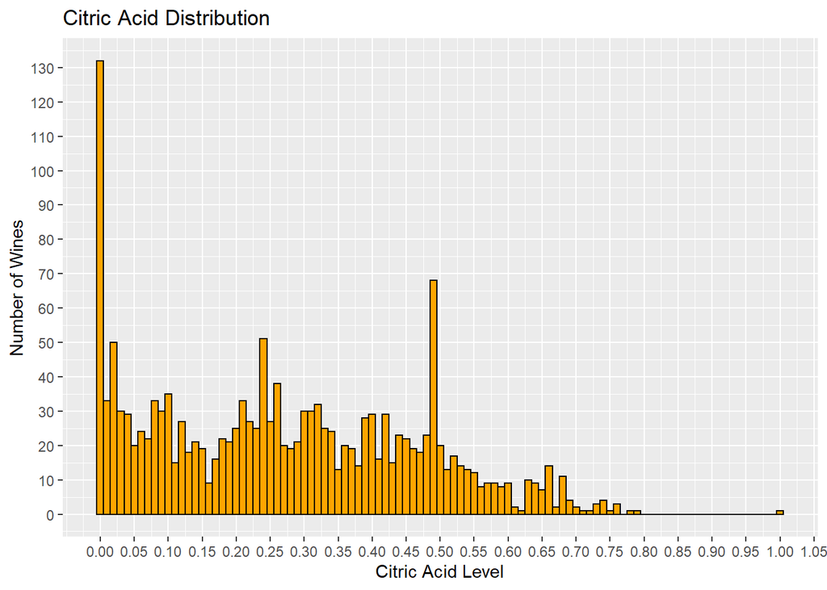

### Plot Two

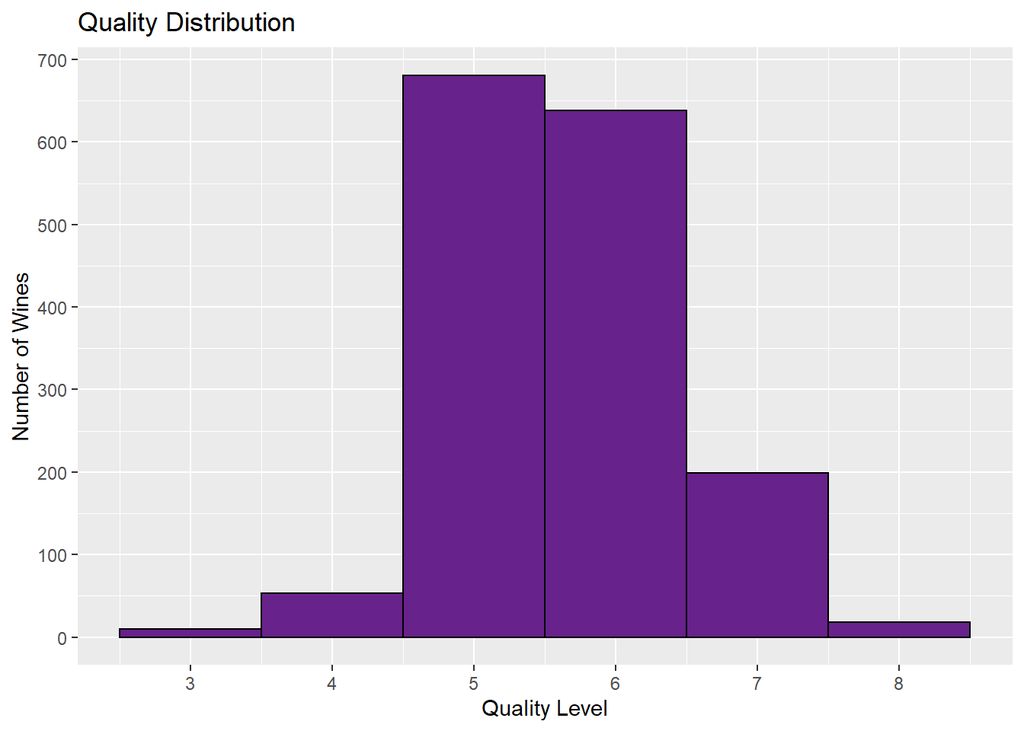

### Description Two

Quality level of red wines was also very interesting. I was expecting to see many more higher rated wines but a majority of the dataset hovered around a 5 and 6 rating. It appears that most wines out there are considered “average”.

### Plot Three

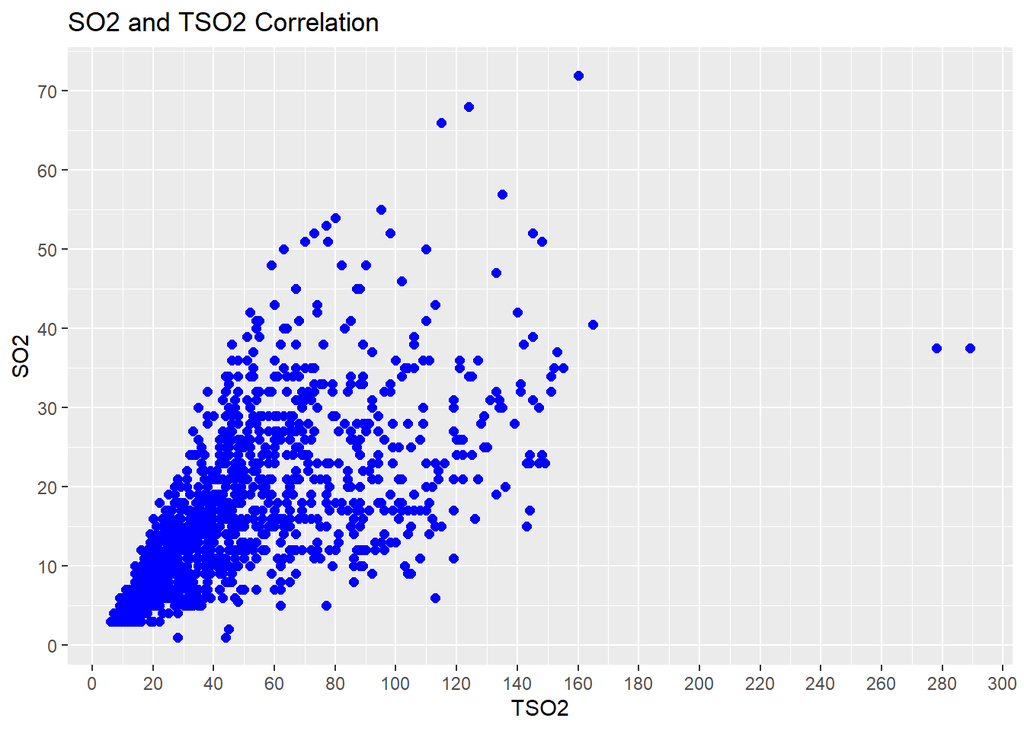

### Description Three

The final graph I thought was interesting was the correlation between free sulfur dioxide and total sulfur dioxide. I was not expecting for both to have a positive correlation because in my mind, I see that one type would cause a negative impact on the other, similar to using gasoline in a diesel car.

# Reflection

Coming into this datset I had no idea what kind of variables determine how a red wine(or any wine) is rated. I do not consume alcohol so I wouldn’t know what a good wine even tastes like. I probably would think they’re all the same.

One struggle I ran into was the small amount of variables that affected my main focus(quality). They were so similar in correlation that not many of them stood out. On the flip side, comparing other variables with each other were a little easier due to their higher correlations.

Regarding the dataset, I believe that a much larger dataset would achieve betterresults. Since a majority of the dataset hovered around a 5 and 6 quality rating, I would’ve liked to see more wines that were of a much better quality.

Overall, the most surprising thing about this dataset was the amount of variables that go into making a quality wine. I can’t believe how scientific the research gets and now understand that wine making is simply an art form and should be respected.